# Машинное обучение в бизнесе-git

```python
import pandas as pd
import numpy as np
import shap
from termcolor import colored # цвет
from matplotlib import pyplot as plt # графики
import seaborn as sns # графики
from scipy.stats import pearsonr
import phik # расчет коэффициентов корреляции
import copy

# загружаем классы для подготовки данных
from sklearn.preprocessing import (
    OneHotEncoder
    ,OrdinalEncoder
    ,StandardScaler
    ,MinMaxScaler
    ,RobustScaler
    ,PolynomialFeatures
)

from sklearn.compose import ColumnTransformer
from sklearn.preprocessing import LabelEncoder
from sklearn.cluster import KMeans # метод кластеризации
from sklearn.impute import SimpleImputer # загружаем класс для работы с пропусками
from sklearn.model_selection import RandomizedSearchCV, GridSearchCV, train_test_split # импортируем класс RandomizedSearchCV

# загружаем нужные модели
from sklearn.linear_model import LogisticRegression, LinearRegression
from sklearn.neighbors import KNeighborsClassifier
from sklearn.tree import DecisionTreeClassifier
from sklearn.svm import SVC

# загружаем класс pipeline
from sklearn.pipeline import Pipeline

# анализ эффективности модели
from sklearn.metrics import (
 roc_auc_score # загружаем функцию для работы с метриками
 ,mean_absolute_error # расчет ошибки
 ,r2_score # расчет ошибки
 ,mean_squared_error # импорт MSE для RMSE аргумент функции squared = False
 ,confusion_matrix # матрица ошибок (первый/второй год)
 ,accuracy_score # проверка ошибки логистической регрессии
 ,recall_score # ошибки второго рода
 ,precision_score # Ошибки первого рода
)
```

## Загрузка и подготовка данных

```python
geo_data_0 = pd.read_csv('geo_data_0.csv')
geo_data_1 = pd.read_csv('geo_data_1.csv')
geo_data_2 = pd.read_csv('geo_data_2.csv')
```

```python
# Изменение толщины текста
def big_bold_text(text):
    return colored(text, attrs=['bold'])
```

```python
#Создадим словарь соответствия фрейма и его имени
dictionary_with_frames ={
    'geo_data_0': geo_data_0,
    'geo_data_1': geo_data_1,
    'geo_data_2': geo_data_2
}
```

**Протестируем данные на дубликаты, пропуски и правильность типов данных**

```python
#Функция тестировани данных
def test_df (dictionary_with_frames_col):
    for row in dictionary_with_frames_col:
        print(big_bold_text('Таблица: '),row)
        print(big_bold_text('Количество дубликатов: '),dictionary_with_frames[row].duplicated().sum())
        if dictionary_with_frames[row].duplicated().sum()>0:
            print('')
            print(big_bold_text('Строки с дубликатами:'))
            display(dictionary_with_frames[row].loc[dictionary_with_frames[row].duplicated()==True])
        print('')
        print(big_bold_text('Информация по таблице\n'))
        dictionary_with_frames[row].info()
        print('')
        print(big_bold_text('Количество пропусков:\n'))
        print(dictionary_with_frames[row].isna().sum())
        print('')
        print(big_bold_text('Вывод первых 5 строк из таблицы\n'))
        display(dictionary_with_frames[row].head(5))
        print(big_bold_text('_____________________________________________________________________________________________________'))
        print('')
test_df(dictionary_with_frames)
```

```
Таблица:  geo_data_0
Количество дубликатов:  0

Информация по таблице

<class 'pandas.core.frame.DataFrame'>
RangeIndex: 100000 entries, 0 to 99999
Data columns (total 5 columns):
 #   Column   Non-Null Count   Dtype
---  ------   --------------   -----
 0   id       100000 non-null  object
 1   f0       100000 non-null  float64
 2   f1       100000 non-null  float64
 3   f2       100000 non-null  float64
 4   product  100000 non-null  float64
dtypes: float64(4), object(1)
memory usage: 3.8+ MB

Количество пропусков:

id         0
f0         0
f1         0
f2         0
product    0
dtype: int64

Вывод первых 5 строк из таблицы
```

|  | id | f0 | f1 | f2 | product |
| --- | --- | --- | --- | --- | --- |
| 0 | txEyH | 0.705745 | -0.497823 | 1.221170 | 105.280062 |
| 1 | 2acmU | 1.334711 | -0.340164 | 4.365080 | 73.037750 |
| 2 | 409Wp | 1.022732 | 0.151990 | 1.419926 | 85.265647 |
| 3 | iJLyR | -0.032172 | 0.139033 | 2.978566 | 168.620776 |
| 4 | Xdl7t | 1.988431 | 0.155413 | 4.751769 | 154.036647 |

```
_____________________________________________________________________________________________________

Таблица:  geo_data_1
Количество дубликатов:  0

Информация по таблице

<class 'pandas.core.frame.DataFrame'>
RangeIndex: 100000 entries, 0 to 99999
Data columns (total 5 columns):
 #   Column   Non-Null Count   Dtype
---  ------   --------------   -----
 0   id       100000 non-null  object
 1   f0       100000 non-null  float64
 2   f1       100000 non-null  float64
 3   f2       100000 non-null  float64
 4   product  100000 non-null  float64
dtypes: float64(4), object(1)
memory usage: 3.8+ MB

Количество пропусков:

id         0
f0         0
f1         0
f2         0
product    0
dtype: int64

Вывод первых 5 строк из таблицы
```

|  | id | f0 | f1 | f2 | product |
| --- | --- | --- | --- | --- | --- |
| 0 | kBEdx | -15.001348 | -8.276000 | -0.005876 | 3.179103 |
| 1 | 62mP7 | 14.272088 | -3.475083 | 0.999183 | 26.953261 |
| 2 | vyE1P | 6.263187 | -5.948386 | 5.001160 | 134.766305 |
| 3 | KcrkZ | -13.081196 | -11.506057 | 4.999415 | 137.945408 |
| 4 | AHL4O | 12.702195 | -8.147433 | 5.004363 | 134.766305 |

```
_____________________________________________________________________________________________________

Таблица:  geo_data_2
Количество дубликатов:  0

Информация по таблице

<class 'pandas.core.frame.DataFrame'>
RangeIndex: 100000 entries, 0 to 99999
Data columns (total 5 columns):
 #   Column   Non-Null Count   Dtype
---  ------   --------------   -----
 0   id       100000 non-null  object
 1   f0       100000 non-null  float64
 2   f1       100000 non-null  float64
 3   f2       100000 non-null  float64
 4   product  100000 non-null  float64
dtypes: float64(4), object(1)
memory usage: 3.8+ MB

Количество пропусков:

id         0
f0         0
f1         0
f2         0
product    0
dtype: int64

Вывод первых 5 строк из таблицы
```

|  | id | f0 | f1 | f2 | product |
| --- | --- | --- | --- | --- | --- |
| 0 | fwXo0 | -1.146987 | 0.963328 | -0.828965 | 27.758673 |
| 1 | WJtFt | 0.262778 | 0.269839 | -2.530187 | 56.069697 |
| 2 | ovLUW | 0.194587 | 0.289035 | -5.586433 | 62.871910 |
| 3 | q6cA6 | 2.236060 | -0.553760 | 0.930038 | 114.572842 |
| 4 | WPMUX | -0.515993 | 1.716266 | 5.899011 | 149.600746 |

```
_____________________________________________________________________________________________________
```

**Построим графики распределения числовых данных**

```
Таблица:  geo_data_0
Наименование столбца:  f0
```

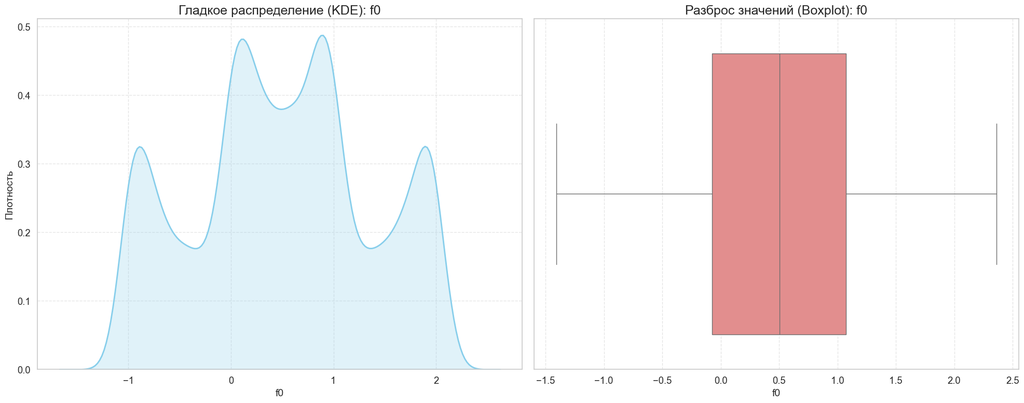

```
Наименование столбца:  f1
```

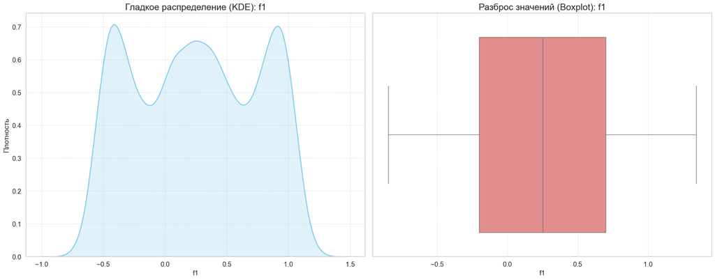

```
Наименование столбца:  f2
```

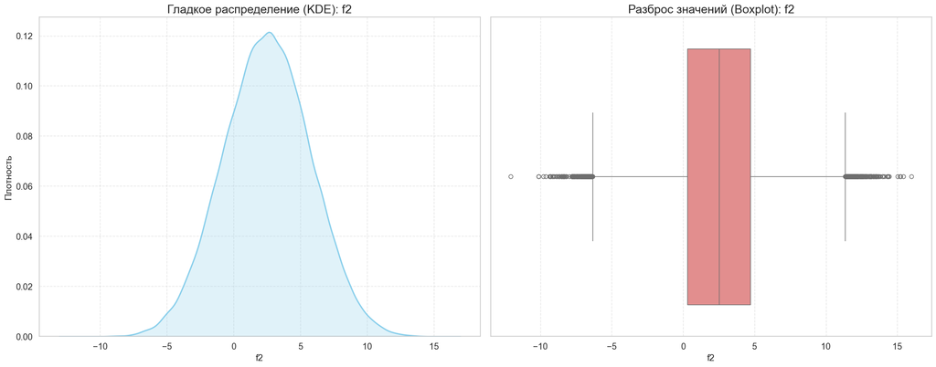

```
Наименование столбца:  product
```

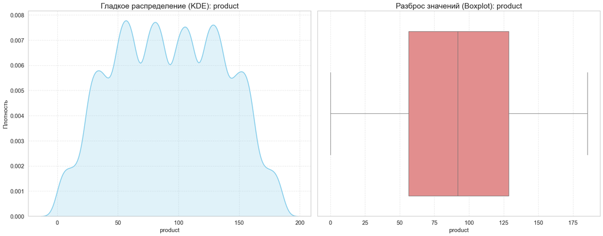

```
Таблица:  geo_data_1
Наименование столбца:  f0
```

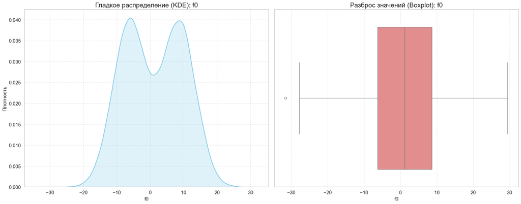

```
Наименование столбца:  f1
```

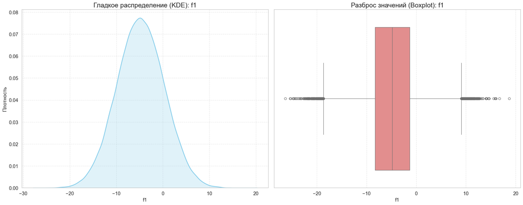

```
Наименование столбца:  f2
```

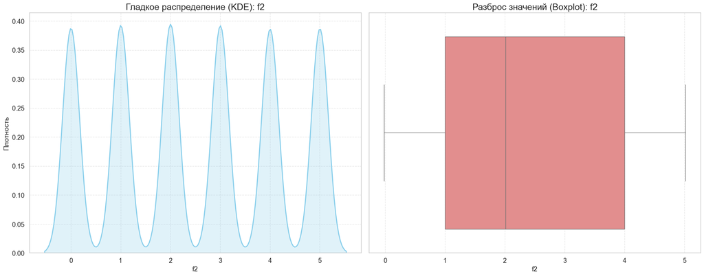

```
Наименование столбца:  product
```

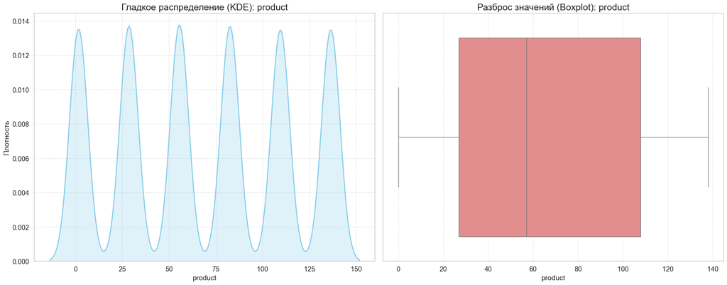

```
Таблица:  geo_data_2
Наименование столбца:  f0
```

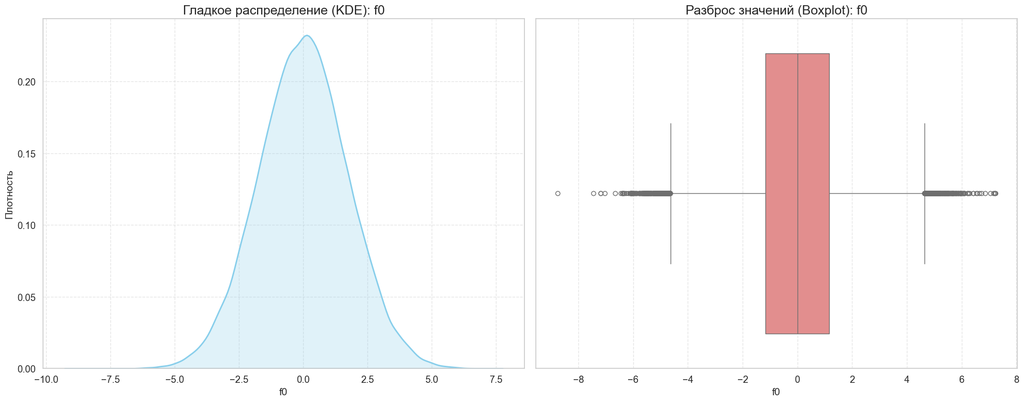

```
Наименование столбца:  f1
```

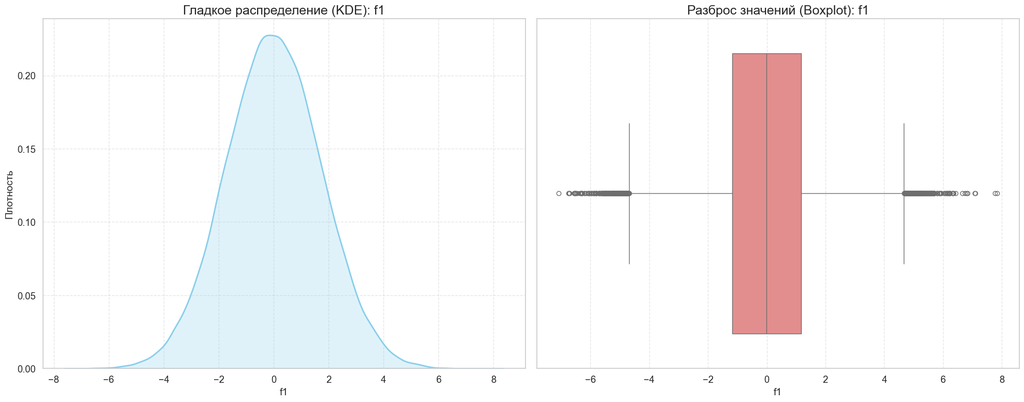

```
Наименование столбца:  f2
```

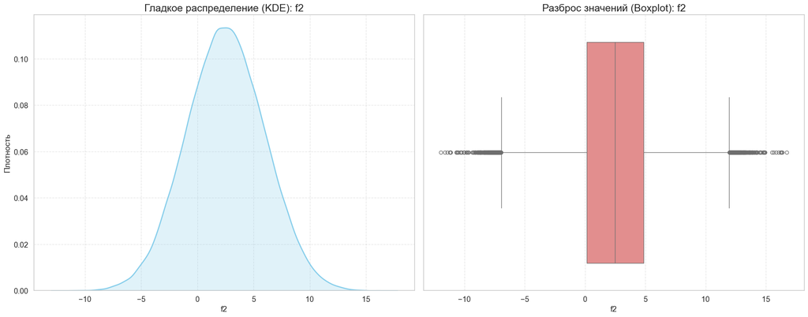

```
Наименование столбца:  product
```

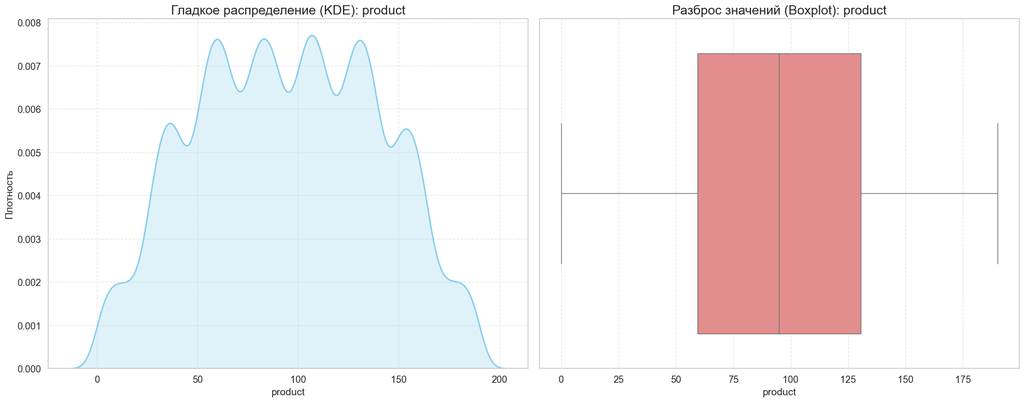

```python
sns.set(style='whitegrid', font_scale=1.2)
palette = sns.color_palette('pastel')

for table_name in dictionary_with_frames:
    print(big_bold_text('Таблица: '), table_name)

    df = dictionary_with_frames[table_name]

    numeric_cols = df.select_dtypes(include='number').columns

    for col in numeric_cols:
        print(big_bold_text('Наименование столбца: '), col)

        fig, axes = plt.subplots(1, 2, figsize=(20, 8))

        # --- KDE Plot ---
        sns.kdeplot(data=df, x=col, ax=axes[0], fill=True, color='skyblue', linewidth=2)
        axes[0].set_title(f'Гладкое распределение (KDE): {col}', fontsize=18)
        axes[0].set_xlabel(col, fontsize=14)
        axes[0].set_ylabel('Плотность', fontsize=14)
        axes[0].grid(True, linestyle='--', alpha=0.5)

        # --- Boxplot ---
        sns.boxplot(x=df[col], ax=axes[1], color='lightcoral', orient='h')
        axes[1].set_title(f'Разброс значений (Boxplot): {col}', fontsize=18)
        axes[1].set_xlabel(col, fontsize=14)
        axes[1].grid(True, axis='x', linestyle='--', alpha=0.5)

        plt.tight_layout()
        plt.show()
```

## Обучение и проверка модели

- Сделаем предсказания для каждого региона на вилидной выборке.
- Выведем среднее значение предсказанных данных и метрику RMSE

```python
def model_pred (RANDOM_STATE, TEST_SIZE, data):
    indices = data.index
    # Разбиваем данные на выборки
    X_train, X_valid, y_train, y_valid, idx_train, idx_valid = train_test_split(
    data.drop(['id','product'], axis=1),
    data['product'],
    indices,
    test_size = TEST_SIZE,
    random_state = RANDOM_STATE
    )
    # Наименование числовых столбцов
    num_columns = X_train.columns

    # Описываем пайплайн
    num_pipe = Pipeline([
    ('simpleImputer_num', SimpleImputer(strategy='median')),
    ('poly', PolynomialFeatures()),  # Шаг добавления полиномиальных признаков
    ('scaler', StandardScaler())     # Масштабирование
    ])

    # ColumnTransformer для обработки признаков
    data_preprocessor = ColumnTransformer([
        ('num', num_pipe, num_columns),  # Обработка числовых признаков
    ])

    # Итоговый пайплайн: подготовка данных и модель
    pipe_final = Pipeline([
        ('preprocessor', data_preprocessor),
        ('models', LinearRegression())  # Заглушка для модели, будет изменяться в поиске параметров
    ])

    # Сетка гиперпараметров для GridSearchCV, включая степень полинома
    param_grid = [
        {
            'models': [LinearRegression()],
            'preprocessor__num__scaler': [StandardScaler(), MinMaxScaler(), RobustScaler(), 'passthrough'],
            'preprocessor__num__poly__degree': [1, 2, 3, 4, 5]  # Подбор степени полинома
        }
    ]
    # GridSearchCV для поиска лучших параметров
    grid_search = GridSearchCV(
        pipe_final,
        param_grid=param_grid,
        cv=5,  # Кросс-валидация на 5 фолдов
        scoring='neg_mean_squared_error',
        n_jobs=-1  # Параллельное выполнение
    )

    # Обучение модели
    grid_search.fit(X_train, y_train)

    best_mse_train = -grid_search.best_score_  # Это средняя MSE для лучшей модели
    best_rmse_train = np.sqrt(best_mse_train)

    # Предсказание

    y_pred = grid_search.predict(X_valid)
    rmse_valid = mean_squared_error(y_valid,y_pred,squared = False)
    y_pred_mean = y_pred.mean()

    return grid_search, best_rmse_train, rmse_valid, y_pred_mean, idx_valid
```

```python
RANDOM_STATE = 42
TEST_SIZE = 0.25
model = []
valid_indices = []
for row in dictionary_with_frames:
    grid_search, best_rmse_train, rmse_valid, y_pred_mean, idx_valid = model_pred(RANDOM_STATE = RANDOM_STATE, TEST_SIZE = TEST_SIZE, data = dictionary_with_frames[row])
    model.append(grid_search)
    valid_indices.append(idx_valid)
    print(big_bold_text('{:}: '.format(row)), big_bold_text('RMSE_train: '), best_rmse_train, \
          big_bold_text('y_pred_mean:'), round(y_pred_mean.mean(),2), big_bold_text('RMSE_valid:'), round(rmse_valid,2), \
          big_bold_text('RMSE/y_pred_mean:'), round(rmse_valid/y_pred_mean.mean()*100,2))
```

```
geo_data_0:  RMSE_train:  37.088379513826396 y_pred_mean: 92.47 RMSE_valid: 37.2 RMSE/y_pred_mean: 40.22
geo_data_1:  RMSE_train:  0.7484181835593173 y_pred_mean: 68.72 RMSE_valid: 0.75 RMSE/y_pred_mean: 1.09
geo_data_2:  RMSE_train:  38.17015212784137 y_pred_mean: 94.72 RMSE_valid: 38.29 RMSE/y_pred_mean: 40.43
```

**Вывод:**

1. Модель хорошо предсказывает данные в регионе с geo_data = 1. Отношение rmse к среднему значению не более 2% в большую или меньшую сторону.
2. В других регионах модель плохо обучается. Необходим больший объем данных или больше входных параметров. Это также связано с тем, что целевой признак распределен не нормально и имеет несколько пик

## Подготовка к расчёту прибыли

Для обучения модели подходит только линейная регрессия (остальные — недостаточно предсказуемые).

При разведке региона исследуют 500 точек, из которых с помощью машинного обучения выбирают 200 лучших для разработки.

Бюджет на разработку скважин в регионе — 10 млрд рублей.

При нынешних ценах один баррель сырья приносит 450 рублей дохода. Доход с каждой единицы продукта составляет 450 тыс. рублей, поскольку объём указан в тысячах баррелей.

После оценки рисков нужно оставить лишь те регионы, в которых вероятность убытков меньше 2.5%. Среди них выбирают регион с наибольшей средней прибылью.

```python
# Инвестиции в регион (разработка скважит)
INV = 10000000000
```

```python
# Количество разрабатываемых точек в регионе
POINT = 200
```

```python
# Себестоимость разработки одной точки
cost_point = INV/POINT
print('Себестоимость одной точки: ', f"{cost_point:,.2f}")
```

```
Себестоимость одной точки:  50,000,000.00
```

```python
# Доход с каждой единицы
UNIT_VALUE = 450000
```

```python
# Безубыточный объем сырья общий на все скважины
volume = INV/UNIT_VALUE
print('Общий объем сырья для безубыточной разведки: ', f"{volume:,.0f}")
```

```
Общий объем сырья для безубыточной разведки:  22,222
```

```python
# Безубыточный объем сырья на одну точку
volume_point = INV/UNIT_VALUE/POINT
print('Объем сырья на одну точку: ', f"{volume_point:,.2f}")
for row in dictionary_with_frames:
    all_val_1_unit = round(dictionary_with_frames[row]['product'].mean(),2)
    print('Средний объем сырья {:}: '.format(row), f"{all_val_1_unit:,.2f}")
```

```
Объем сырья на одну точку:  111.11
Средний объем сырья geo_data_0:  92.50
Средний объем сырья geo_data_1:  68.83
Средний объем сырья geo_data_2:  95.00
```

```python
#Доход с 1 скажины (средний)
for row in dictionary_with_frames:
    all_val_1_unit = round(dictionary_with_frames[row]['product'].mean(),2)*UNIT_VALUE
    print('Средний объем сырья {:}: '.format(row), f"{all_val_1_unit:,.2f}")
```

```
Средний объем сырья geo_data_0:  41,625,000.00
Средний объем сырья geo_data_1:  30,973,500.00
Средний объем сырья geo_data_2:  42,750,000.00
```

```python
for row in dictionary_with_frames:
    count_geo = round(INV/(dictionary_with_frames[row]['product'].mean()*UNIT_VALUE))
    print('Количество скважин, которые окупят вложения {:}: '.format(row), f"{count_geo:,.0f}")
```

```
Количество скважин, которые окупят вложения geo_data_0:  240
Количество скважин, которые окупят вложения geo_data_1:  323
Количество скважин, которые окупят вложения geo_data_2:  234
```

**Вывод:**

1. Среднее значение объема сырья одной точки для окупаемости выше, чем среднее значение запасов сырья одной точки в регионе

## Расчёт прибыли и рисков

Напишите функцию для расчёта прибыли по выбранным скважинам и предсказаниям модели:

4.1. Выберите скважины с максимальными значениями предсказаний.

4.2. Просуммируйте целевое значение объёма сырья, соответствующее этим предсказаниям.

4.3. Рассчитайте прибыль для полученного объёма сырья.

```python
# Функция расчета прибыли
def profit_cash (data, model, volume_point, unit_value, inv):
    #geo_data_pred = copy.deepcopy(data)
    product_pred = model.predict(data[['f0','f1','f2']])
    data['product_pred'] = product_pred
    # Объем полученного сырья
    volume_all = data.loc[data['product_pred']>=volume_point]\
    .sort_values(by = 'product_pred', ascending = False).head(200)['product_pred'].sum()
    # Общая прибыль от полученного сырья
    # Выручка
    revenue = volume_all*unit_value
    # Прибыль
    profit = revenue-inv
    return revenue, profit
```

```python
data = [geo_data_0, geo_data_1, geo_data_2]
for i in range(0, 3):
    revenue, profit = profit_cash(data = data[i], model = model[i], volume_point = volume_point, unit_value = UNIT_VALUE, inv = INV)
    print('Выручка geo_{:}: '.format(i), f"{revenue:,.2f}")
    print('Прибыль geo_{:}: '.format(i), f"{profit:,.2f}")
    print('')
    revenue = 0
    profit = 0
```

```
Выручка geo_0:  13,706,275,208.83
Прибыль geo_0:  3,706,275,208.83

Выручка geo_1:  12,454,696,556.09
Прибыль geo_1:  2,454,696,556.09

Выручка geo_2:  14,342,514,564.24
Прибыль geo_2:  4,342,514,564.24
```

**Вывод по прибыли:**

- С точки зрения прибыли, наиболее выгодный регион для вложения инвестиций регион № 2. Однако, в регионе 1 модель МО давала самое низкое значение RMSE, как в абсолютных значениях, так и в процентном соотношении к среднему значению сырья на скважину

**Расчет рисков**

Посчитайте риски и прибыль для каждого региона:

5.1. Примените технику Bootstrap с 1000 выборок, чтобы найти распределение прибыли.

5.2. Найдите среднюю прибыль, 95%-й доверительный интервал и риск убытков. Убыток — это отрицательная прибыль.

5.3. Напишите выводы: предложите регион для разработки скважин и обоснуйте выбор.

```python
def calculate_profit(real, predicted, unit_value, inv, state, count, size):
    state = np.random.RandomState(state)
    profits = []

    for i in range(count):
        # Семплируем 500 случайных скважин
        sample_indices = state.choice(real.index, size=500, replace=False)
        real_sample = real.loc[sample_indices]
        predicted_sample = predicted.loc[sample_indices]

        # Выбираем 200 лучших скважин на основе предсказанных значений
        top_predicted_indices = predicted_sample.sort_values(ascending=False).head(200).index
        real_top_wells = real_sample.loc[top_predicted_indices]

        # Напечатать размер объекта real_top_wells
        #print(f"Итерация {i + 1}: Размер real_top_wells: {real_top_wells.shape[0]} скважин")
        #print('index', real_top_wells.index)
        #print('unique index', real_top_wells.index.unique)

        # Считаем прибыль, используя реальные значения
        revenue = real_top_wells.sum() * unit_value - inv
        profits.append(revenue)

    # Преобразуем в pandas Series для анализа
    profits = pd.Series(profits)

    # Рассчитываем необходимые статистики
    mean_profit = profits.mean()
    lower_confidence_interval = profits.quantile(0.025)
    upper_confidence_interval = profits.quantile(0.975)
    loss_risk = (profits < 0).mean()

    return mean_profit, lower_confidence_interval, upper_confidence_interval, loss_risk
```

```python
# Пример использования функции для каждого региона
for i in range(3):
    real_values = data[i].iloc[valid_indices[i]]['product']  # Реальные значения
    predicted_values = data[i].iloc[valid_indices[i]]['product_pred']  # Предсказанные значения
    mean_profit, lower_confidence_interval, upper_confidence_interval, loss_risk = calculate_profit(
        real=real_values, predicted=predicted_values,
        unit_value=UNIT_VALUE, inv=INV, state=12345, count=1000, size=500
    )
    print(f'Среднее значение прибыли: {mean_profit:,.2f}')
    print(f'95%-й доверительный интервал: {lower_confidence_interval:,.2f} - {upper_confidence_interval:,.2f}')
    print(f'Риск убытков: {loss_risk:.2%}')
    print('')
```

```
Среднее значение прибыли: 470,956,704.34
95%-й доверительный интервал: -39,279,566.51 - 975,502,602.77
Риск убытков: 3.30%

Среднее значение прибыли: 442,488,403.35
95%-й доверительный интервал: 28,958,037.44 - 834,438,101.75
Риск убытков: 1.90%

Среднее значение прибыли: 626,254,970.27
95%-й доверительный интервал: 127,628,436.22 - 1,132,893,592.42
Риск убытков: 0.80%
```